# IntroductiontoComputerVisionProject

```python
# Import libraries
from tensorflow import keras
from tensorflow.keras.preprocessing.image import ImageDataGenerator
from tensorflow.keras.models import Sequential
from tensorflow.keras.layers import Dense, Dropout, Activation, Flatten
from tensorflow.keras.layers import Conv2D, MaxPooling2D
import matplotlib.pyplot as plt
%matplotlib inline
import cv2
from google.colab.patches import cv2_imshow
import numpy as np
from scipy.ndimage.filters import gaussian_filter
```

```python
from google.colab import drive
drive.mount('/content/drive/')
```

```python
project_path = '/content/drive/My Drive/Colab Notebooks/7_IntroductiontoComputerVision/'
#Set project path for labels
dataset_file_labels = project_path + 'Labels.csv'
```

```python
#import the labels into a data frame
import pandas as pd
data = pd.read_csv(dataset_file_labels)
```

```python
data.head()
```

|  | Label |
| --- | --- |
| 0 | Small-flowered Cranesbill |
| 1 | Small-flowered Cranesbill |
| 2 | Small-flowered Cranesbill |
| 3 | Small-flowered Cranesbill |
| 4 | Small-flowered Cranesbill |

```python
data.shape
```

```
(4750, 1)
```

```python
datafile_img=project_path+'images.npy'
```

```python
data_img = np.load(datafile_img)
```

```python
len(data_img)
```

```
4750
```

```python
data_img.shape
```

```
(4750, 128, 128, 3)
```

```python
data['Label'].value_counts()
```

```
Loose Silky-bent             654
Common Chickweed             611
Scentless Mayweed            516
Small-flowered Cranesbill    496
Fat Hen                      475
Charlock                     390
Sugar beet                   385
Cleavers                     287
Black-grass                  263
Shepherds Purse              231
Maize                        221
Common wheat                 221
Name: Label, dtype: int64
```

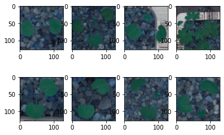

```python
# Visualize Images in Data Set
from matplotlib import pyplot as plt
from PIL import Image
for i in range(8):
    plt.subplot(2, 4, i + 1)
    plt.imshow(data_img[i])
```

```python
images=data_img
classes=data
```

```python
images=images/255.0 # Division by 255
```

```python
#Apply Gaussian blur sigma=.8 after multiple iterations
blurred = gaussian_filter(images, sigma=.8)
```

Visualize Original Data Before applying gaussian blur

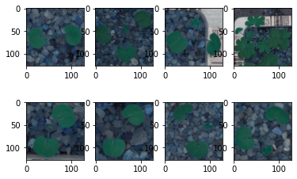

```python
from matplotlib import pyplot as plt
from PIL import Image
for i in range(8):
    plt.subplot(2, 4, i + 1)
    plt.imshow(data_img[i])
```

Visualize images after applying Gaussian blur

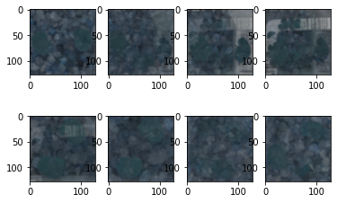

```python
from matplotlib import pyplot as plt
from PIL import Image
for i in range(8):
    plt.subplot(2, 4, i + 1)
    plt.imshow(blurred[i])
```

Normalization of labels

```python
from sklearn.preprocessing import LabelBinarizer
enc = LabelBinarizer()
y = enc.fit_transform(data)
```

```python
y[0]
```

```
array([0, 0, 0, 0, 0, 0, 0, 0, 0, 0, 1, 0])
```

```python
images=blurred
```

Split the dataset into training, testing, and validation set.

```python
from sklearn.model_selection import train_test_split
X_train, X_test, y_train, y_test = train_test_split(images, y, test_size=0.3, random_state=7)
```

```python
random_seed = 3
from sklearn.model_selection import train_test_split
X_test, X_val, y_test, Y_val = train_test_split(X_test,y_test, test_size = 0.5, random_state=random_seed)
```

Check the shape of data, Reshape data into shapes compatible with Keras models if it’s not already. If it’s already in the compatible shape, then comment in the notebook that it’s already in compatible shape.

```python
data_img.shape
```

```
(4750, 128, 128, 3)
```

Sequential model in tensorflow.keras expects data to be in the format (n_e, n_h, n_w, n_c) n_e= number of examples, n_h = height, n_w = width, n_c = number of channels Since the data images are aleady in the required shape, there is no need to re-shape the data

Build CNN Models and Define Layers

```python
from keras.utils.np_utils import to_categorical
from keras.models import Sequential
from keras.layers import Dense, Dropout, Flatten, Conv2D, MaxPool2D, GlobalMaxPooling2D
from keras.optimizers import RMSprop
from keras.preprocessing.image import ImageDataGenerator
from keras.optimizers import Adam
```

```python
batch_size = None

model = Sequential()

model.add(Conv2D(filters = 32, kernel_size = (5,5),padding = 'Same',
                 activation ='relu', batch_input_shape = (batch_size,128, 128, 3)))


model.add(Conv2D(filters = 32, kernel_size = (5,5),padding = 'Same',
                 activation ='relu'))
model.add(MaxPool2D(pool_size=(2,2)))
model.add(Dropout(0.2))


model.add(Conv2D(filters = 64, kernel_size = (3,3),padding = 'Same',
                 activation ='relu'))
model.add(Conv2D(filters = 64, kernel_size = (3,3),padding = 'same',
                 activation ='relu'))
model.add(MaxPool2D(pool_size=(2,2), strides=(2,2)))
model.add(Dropout(0.3))

model.add(Conv2D(filters = 128, kernel_size = (3,3),padding = 'Same',
                 activation ='relu'))
model.add(Conv2D(filters = 128, kernel_size = (3,3),padding = 'Same',
                 activation ='relu'))
model.add(MaxPool2D(pool_size=(2,2), strides=(2,2)))
model.add(Dropout(0.4))



model.add(GlobalMaxPooling2D())
model.add(Dense(128, activation = "relu"))
model.add(Dropout(0.5))
model.add(Dense(12, activation = "softmax"))
model.summary()
```

```
Model: "sequential"
_________________________________________________________________
Layer (type)                 Output Shape              Param #
=================================================================
conv2d (Conv2D)              (None, 128, 128, 32)      2432
_________________________________________________________________
conv2d_1 (Conv2D)            (None, 128, 128, 32)      25632
_________________________________________________________________
max_pooling2d (MaxPooling2D) (None, 64, 64, 32)        0
_________________________________________________________________
dropout (Dropout)            (None, 64, 64, 32)        0
_________________________________________________________________
conv2d_2 (Conv2D)            (None, 64, 64, 64)        18496
_________________________________________________________________
conv2d_3 (Conv2D)            (None, 64, 64, 64)        36928
_________________________________________________________________
max_pooling2d_1 (MaxPooling2 (None, 32, 32, 64)        0
_________________________________________________________________
dropout_1 (Dropout)          (None, 32, 32, 64)        0
_________________________________________________________________
conv2d_4 (Conv2D)            (None, 32, 32, 128)       73856
_________________________________________________________________
conv2d_5 (Conv2D)            (None, 32, 32, 128)       147584
_________________________________________________________________
max_pooling2d_2 (MaxPooling2 (None, 16, 16, 128)       0
_________________________________________________________________
dropout_2 (Dropout)          (None, 16, 16, 128)       0
_________________________________________________________________
global_max_pooling2d (Global (None, 128)               0
_________________________________________________________________
dense (Dense)                (None, 128)               16512
_________________________________________________________________
dropout_3 (Dropout)          (None, 128)               0
_________________________________________________________________
dense_1 (Dense)              (None, 12)                1548
=================================================================
Total params: 322,988
Trainable params: 322,988
Non-trainable params: 0
_________________________________________________________________
```

```python
from keras.optimizers import RMSprop
from keras.optimizers import Adam
opt = Adam(lr=0.001)

optimizer = RMSprop(lr=0.001, rho=0.9, epsilon=1e-08, decay=0.0)
model.compile(optimizer = optimizer, loss = "categorical_crossentropy", metrics = ["accuracy"])
```

```python
datagen = ImageDataGenerator(
        featurewise_center=False,  # set input mean to 0 over the dataset
        samplewise_center=False,  # set each sample mean to 0
        featurewise_std_normalization=False,  # divide inputs by std of the dataset
        samplewise_std_normalization=False,  # divide each input by its std
        zca_whitening=False,  # apply ZCA whitening
        rotation_range=10,  # randomly rotate images in the range (degrees, 0 to 180)
        zoom_range = 0.1, # Randomly zoom image
        width_shift_range=0.1,  # randomly shift images horizontally (fraction of total width)
        height_shift_range=0.1,  # randomly shift images vertically (fraction of total height)
        horizontal_flip=False,  # randomly flip images
        vertical_flip=False)  # randomly flip images


datagen.fit(X_train)
```

Fit and evaluate model and print confusion matrix

```python
model.fit(X_train, y_train, epochs = 150, validation_data = (X_val,Y_val),batch_size = batch_size)
```

```
<tensorflow.python.keras.callbacks.History at 0x7f79c811d590>
```

```python
score = model.evaluate(X_test, y_test, verbose=0, batch_size = 38)
print('loss Test Data:', score[0])
print('accuracy Test Data:', score[1])
```

```
loss Test Data: 0.4784281551837921
accuracy Test Data: 0.8202247023582458
```

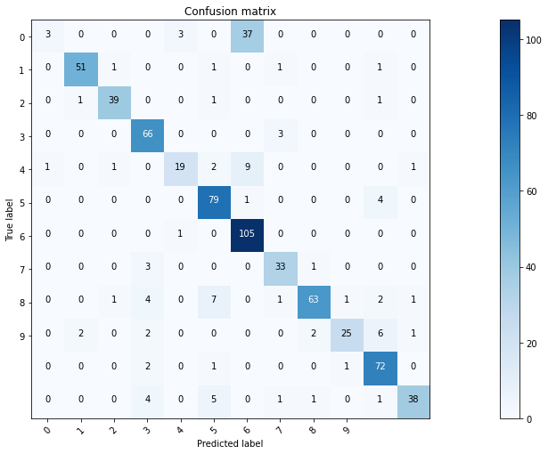

```python
from sklearn.metrics import confusion_matrix
import itertools
plt.subplots(figsize=(22,7)) #set the size of the plot

def plot_confusion_matrix(cm, classes,
                          normalize=False,
                          title='Confusion matrix',
                          cmap=plt.cm.Blues):
    """
    This function prints and plots the confusion matrix.
    Normalization can be applied by setting `normalize=True`.
    """
    plt.imshow(cm, interpolation='nearest', cmap=cmap)
    plt.title(title)
    plt.colorbar()
    tick_marks = np.arange(len(classes))
    plt.xticks(tick_marks, classes, rotation=45)
    plt.yticks(tick_marks, classes)

    if normalize:
        cm = cm.astype('float') / cm.sum(axis=1)[:, np.newaxis]

    thresh = cm.max() / 2.
    for i, j in itertools.product(range(cm.shape[0]), range(cm.shape[1])):
        plt.text(j, i, cm[i, j],
                 horizontalalignment="center",
                 color="white" if cm[i, j] > thresh else "black")

    plt.tight_layout()
    plt.ylabel('True label')
    plt.xlabel('Predicted label')

# Predict the values from the validation dataset
Y_pred = model.predict(X_val)
# Convert predictions classes to one hot vectors
Y_pred_classes = np.argmax(Y_pred,axis = 1)
# Convert validation observations to one hot vectors
Y_true = np.argmax(Y_val,axis = 1)
# compute the confusion matrix
confusion_mtx = confusion_matrix(Y_true, Y_pred_classes)
# plot the confusion matrix
plot_confusion_matrix(confusion_mtx, classes = range(10))
```

```python
Predicted_classes = model.predict_classes(X_test)
```

```python
wrong_preds = X_test[Predicted_classes != np.argmax(y_test)]
```

```python
set(Predicted_classes)
```

```
{0, 1, 2, 3, 4, 5, 6, 7, 8, 9, 10, 11}
```

```python
i=2
```

```
Predicted class: Fat Hen
Actual class: Fat Hen
```

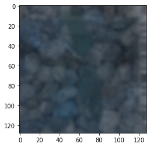

```python
pred = model.predict_classes(np.array([wrong_preds[i]]))[0]
act = np.argmax(y_test[i])
print("Predicted class: {}".format(enc.classes_[pred]))
print("Actual class: {}".format(enc.classes_[act]))

plt.imshow(wrong_preds[i])
```

Visualize predictions for x_test[2], x_test[3], x_test[33], x_test[36], x_test[59].

```python
i=3
```

```
Predicted class: Fat Hen
Actual class: Fat Hen
```

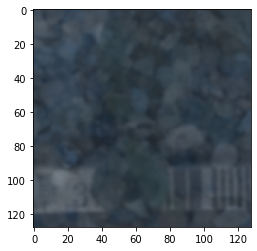

```python
pred = model.predict_classes(np.array([wrong_preds[i]]))[0]
act = np.argmax(y_test[i])
print("Predicted class: {}".format(enc.classes_[pred]))
print("Actual class: {}".format(enc.classes_[act]))

plt.imshow(wrong_preds[i])
```

```
Predicted class: Fat Hen
Actual class: Shepherds Purse
```

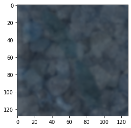

```python
i=33
pred = model.predict_classes(np.array([wrong_preds[i]]))[0]
act = np.argmax(y_test[i])
print("Predicted class: {}".format(enc.classes_[pred]))
print("Actual class: {}".format(enc.classes_[act]))

plt.imshow(wrong_preds[i])
```

```
Predicted class: Loose Silky-bent
Actual class: Maize
```

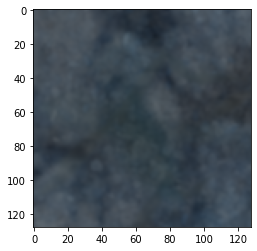

```python
i=36
pred = model.predict_classes(np.array([wrong_preds[i]]))[0]
act = np.argmax(y_test[i])
print("Predicted class: {}".format(enc.classes_[pred]))
print("Actual class: {}".format(enc.classes_[act]))

plt.imshow(wrong_preds[i])
```

```
Predicted class: Fat Hen
Actual class: Loose Silky-bent
```

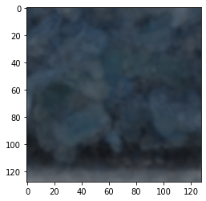

```python
i=59
pred = model.predict_classes(np.array([wrong_preds[i]]))[0]
act = np.argmax(y_test[i])
print("Predicted class: {}".format(enc.classes_[pred]))
print("Actual class: {}".format(enc.classes_[act]))

plt.imshow(wrong_preds[i])
```